# Statistical tests

## What will we learn in the empirical session ?

1. Estimating the variance of the residuals and the variance of the OLS estimator.
2. Performing a t-test.
3. Computing a confidence interval.
4. Computing the p-value.

## Theory behind the exercise

We consider the CAPM given by,

$$y_t = \beta_1 + \beta_2 x_t + \epsilon_t,$$
in which $y_t$ and $x_t$ stand for the excess returns of a stock and of the market, respectively. To estimate the linear coefficients, we minimize the sum of squared residuals (SSR) that is expressed as
$$\text{min} \sum_{t=1}^{T}\epsilon_t^2 = \text{min} \sum_{t=1}^{T}(y_t - \beta_1 - \beta_2 x_t)^2.$$
The OLS estimators are given by $\hat{\beta}_2 = \frac{\sum_{t=1}^{T}(x_t-\bar{x})(y_t-\bar{y})}{\sum_{t=1}^{T}(x_t-\bar{x})^2}$ and $\hat{\beta}_1 = \bar{y}-\hat{\beta}_2 \bar{x}$. The OLS variances are equal to $V(\hat{\beta}_1|x) = \sigma^2 \frac{\sum_{t=1}^{T}x_t^2}{T\sum_{t=1}^{T}(x_t-\bar{x})^2} = \sigma^2 \tilde{V}(\hat{\beta}_1|x)$ and $V(\hat{\beta}_2|x) = \sigma^2 \frac{1}{\sum_{t=1}^{T}(x_t-\bar{x})^2} = \sigma^2 \tilde{V}(\hat{\beta}_2|x)$ in which $x=(x_1,...,x_T)'$. These variances require to estimate the variance of the residuals. An unbiased and consistent estimate of the residual variance is given by
$$\hat{\sigma}^2 = \frac{1}{T-2} \sum_{t=1}^{T}\hat{\epsilon}_t^2 = \frac{1}{T-2} \sum_{t=1}^{T}(y_t - \hat{\beta}_1 - \hat{\beta}_2 x_t)^2$$
When all the OLS assumptions hold (including the Normality assumption of the residuals), we can show that the OLS estimator is normally distribution, that is
$$\hat{\beta}_i|x \sim N(\beta_i,V(\hat{\beta}_i|x)),~~~~i=1,2.$$
We can standardize the distribution to perform statistical tests. In fact, we have that
$$Z_i \equiv \frac{\hat{\beta}_i - \beta_i}{\sqrt{V(\hat{\beta}_i|x)}} \sim N(0,1),~~~~i=1,2.$$
Since the OLS variances depend on $\sigma^2$ which is not observed, the OLS estimators are only approximately normally distributed when the sample size is large (when $T>100$). To take into account that we use an estimate of the error variance, we have to use the student distribution which exhibits fatter tails than the Normal distribution. In particular, we have that
$$t_{\beta_i} = \frac{\hat{\beta}_i - \beta_i}{\sqrt{V(\hat{\beta}_i|x)}\frac{\hat{\sigma}}{\sigma}} = \frac{\hat{\beta}_i - \beta_i}{\sqrt{\hat{\sigma}^2 \tilde{V}(\hat{\beta}_i|x)}}\sim t(df),~~~~i=1,2,$$
in which *df* stands for the degree of freedom and is equal to $df=T-2$. The student distribution arises since $Z_i \sim N(0,1)$, $\frac{\hat{\sigma}^2}{\sigma^2}\sim \chi^2(df)$ and $\text{Corr}(Z_i,\frac{\hat{\sigma}^2}{\sigma^2}) = 0$. By definition, the ratio of a Normal distribution by the square root of a chi-square distribution leads to a student distribution.

Let us assume that $\beta_2$ should be equal to one according to some economic theory. To reject or not this assumption, we need to carry out a statistical test. If the true coefficient is equal to 1, it means that the true distribution of the OLS estimator is given by,

$$t_{\beta_2} \equiv \frac{\hat{\beta}_2 - 1}{\sqrt{\hat{\sigma}^2 \tilde{V}(\hat{\beta}_2|x)}} \sim t(T-2)\equiv t_{T-2}$$
We can therefore compute the statistics $t_{\beta_2}$ for a given sample and see if it is a likely realization of the student distribution. If not, we reject our assumption. To do a statistical test, we need to fix a significant level $\alpha$ which gives us a threshold over which we consider that the statistics is not a likely value of the student distribution. For instance, if $\alpha=0.05$ and we perform a two-sided test, we will reject the Null hypothesis if $|t_{\beta_2}|>t_{\text{crit}}$ in which $t_{\text{crit}}$ is given by,
$$P[t_{T-2}>t_{crit}^{\alpha}]=\frac{\alpha}{2}$$
From the value $t_{\text{crit}}$, we can also construct a confidence interval given by,
$$[\hat{\beta}_2 - \sqrt{\hat{\sigma}^2 \tilde{V}(\hat{\beta}_2|x)} t_{crit}^{\alpha} ~~ ~~ ~~ ~~ \hat{\beta}_2 + \sqrt{\hat{\sigma}^2 \tilde{V}(\hat{\beta}_2|x)} t_{crit}^{\alpha}]$$
Every value in this interval will not be rejected at a significant level of $\alpha$. This is why we do not say that we accept the Null hypothesis because there are many values that can be accepted. Eventually, we can compute the p-value which tells us at which significant level $\alpha$ the Null hypothesis will be rejected. The p-value for a two-sided test is computed as follows
$$p_{\text{val}} = 2(1-P[t_{T-2}\leq |t_{\beta_2}|])$$

## From theory to practice

We start by loading the data. In this exercise, we consider a simple CAPM in which the free rate is set to 0. We have returns from Amazon and the S&P 500 which is typically used to approximate the market return.

```python
import matplotlib.pyplot as plt
import pandas as pd
import numpy as np
import scipy.stats as stats
import statsmodels.api as sm

url = "https://raw.githubusercontent.com/adufays/GDP_expectancy/main/CAPM%20Exercise.csv"
data = pd.read_csv(url,sep=",")

get_data = np.array(data,ndmin=2,dtype=float)
df_ret=pd.DataFrame(get_data[:,1:(np.size(get_data,1)+1)],columns=data.columns[1:(np.size(get_data,1)+1)])
y = get_data[:,1]
x = get_data[:,2]
```

We first compute the OLS estimates, their variances and the variance of the residuals

```python
x_bar = np.mean(x)
y_bar = np.mean(y)
beta2 = np.sum((x-x_bar)*(y-y_bar))/np.sum((x-x_bar)**2)
beta1 = y_bar - beta2*x_bar

T = np.size(y)
epsi = y-beta1-beta2*x
SSR = sum(epsi**2)
sigma_hat = SSR/(T-2)
var_beta1 = sigma_hat*np.sum(x**2)/(T*np.sum((x-x_bar)**2))
var_beta2 = sigma_hat/(np.sum((x-x_bar)**2))

df=pd.DataFrame(np.array([T,beta1,beta2,var_beta1,var_beta2],ndmin=2),columns=["Obs.","beta1","beta2","var beta1","var beta2"])
print(df)
```

```
##      Obs.     beta1     beta2  var beta1  var beta2
## 0  2033.0  0.066157  1.102894    0.00136   0.001581
```

Since we have 2033 observations, the sample is sufficiently large to let us use the Normal distribution instead of the student distribution. In fact, if we check the quantiles of the Normal distribution, they are very close to those of the student distribution with 2031 degrees of freedom.

```python
quant = np.linspace(0.01, 0.99,num=99)
df = T-2
val_t = stats.t.ppf(quant,df)
val_norm = stats.norm.ppf(quant,0,1)
print(val_t-val_norm)
```

```
## [-1.83746534e-03 -1.31990961e-03 -1.05103393e-03 -8.76406212e-04
##  -7.50600024e-04 -6.54286355e-04 -5.77531771e-04 -5.14593754e-04
##  -4.61871853e-04 -4.16969925e-04 -3.78218589e-04 -3.44411760e-04
##  -3.14651929e-04 -2.88254616e-04 -2.64686864e-04 -2.43526262e-04
##  -2.24432821e-04 -2.07129168e-04 -1.91386297e-04 -1.77013109e-04
##  -1.63848600e-04 -1.51755938e-04 -1.40617904e-04 -1.30333352e-04
##  -1.20814408e-04 -1.11984252e-04 -1.03775326e-04 -9.61278902e-05
##  -8.89888345e-05 -8.23107052e-05 -7.60508941e-05 -7.01709623e-05
##  -6.46360709e-05 -5.94144995e-05 -5.44772362e-05 -4.97976256e-05
##  -4.53510665e-05 -4.11147491e-05 -3.70674261e-05 -3.31892114e-05
##  -2.94614026e-05 -2.58663231e-05 -2.23871802e-05 -1.90079375e-05
##  -1.57131980e-05 -1.24880970e-05 -9.31820253e-06 -6.18942211e-06
##  -3.08791358e-06  6.63880705e-17  3.08791358e-06  6.18942211e-06
##   9.31820253e-06  1.24880970e-05  1.57131980e-05  1.90079375e-05
##   2.23871802e-05  2.58663231e-05  2.94614026e-05  3.31892114e-05
##   3.70674261e-05  4.11147491e-05  4.53510665e-05  4.97976256e-05
##   5.44772362e-05  5.94144995e-05  6.46360709e-05  7.01709623e-05
##   7.60508941e-05  8.23107052e-05  8.89888345e-05  9.61278902e-05
##   1.03775326e-04  1.11984252e-04  1.20814408e-04  1.30333352e-04
##   1.40617904e-04  1.51755938e-04  1.63848600e-04  1.77013109e-04
##   1.91386297e-04  2.07129168e-04  2.24432821e-04  2.43526262e-04
##   2.64686864e-04  2.88254616e-04  3.14651929e-04  3.44411760e-04
##   3.78218589e-04  4.16969925e-04  4.61871853e-04  5.14593754e-04
##   5.77531771e-04  6.54286355e-04  7.50600024e-04  8.76406212e-04
##   1.05103393e-03  1.31990961e-03  1.83746534e-03]
```

```python
fig, ax = plt.subplots(figsize=(10, 10))
plt.plot(val_norm,val_t,'-b',linewidth=3)
ax.set(xlabel="Normal quantiles", ylabel="Student quantiles",title="QQ-plot")
```

```
## [Text(0, 0.5, 'Student quantiles'), Text(0.5, 0, 'Normal quantiles'), Text(0.5, 1.0, 'QQ-plot')]
```

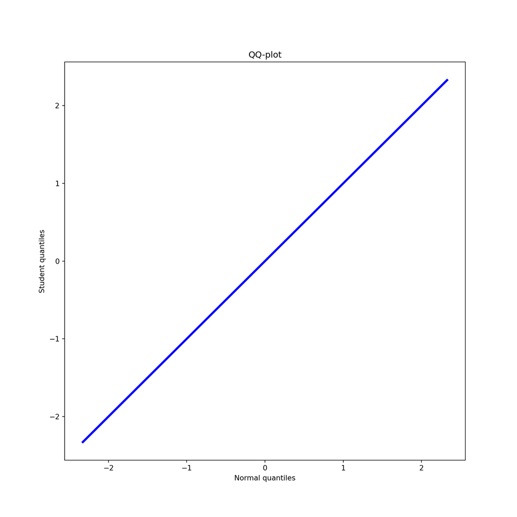

```python
plt.show()
```

The QQ-plot indicates that the two distributions are similar. We can therefore safely use the Normal distribution. Let us carry out the following two-sided test:

$$H_0:\beta_2=1~~~~vs~~~~ H_1:\beta_2 \neq 1$$
We choose a significant level of 99% which corresponds to $\alpha = 0.01$.

```python
alpha = 0.01
Z_crit = stats.norm.ppf(1-alpha/2)
Z_stat = abs((beta2-1))/(np.sqrt(var_beta2))
print([Z_crit,Z_stat])
```

```
## [2.5758293035489004, 2.5879636718739585]
```

The test statistic amounts to 2.588 and the threshold goes up to 2.575. Since $|Z_{\text{stat}}|>Z_{\text{crit}}$, we reject the Null hypothesis. Let us now build a 90% confidence interval.

```python
alpha = 0.1
Z_crit = stats.norm.ppf(1-alpha/2)
Z_stat = abs((beta2-1))/(np.sqrt(var_beta2))
CI = [beta2-Z_crit*np.sqrt(var_beta2),beta2+Z_crit*np.sqrt(var_beta2)]
print(CI)
```

```
## [1.0374966936750631, 1.1682907042407873]
```

The confidence interval at 90% is given by *CI*. It means that the true coefficient has a probability of 90% of belonging to this interval (if the OLS assumptions are true). It also means that any value in this interval won’t be rejected at a significant level of $\alpha=0.1$. Eventually, we can compute the p-value of the test statistic.

```python
p_val = 2*(1-stats.norm.cdf(Z_stat))
print(p_val)
```

```
## 0.009654516206130337
```

The p-value amounts to *p_val*. For any $\alpha \geq$ *p_val*, we reject the Null hypothesis. In this situation, not rejecting the Null hypothesis implies that we need to choose a significant level of at least 99.034.

## Statistical test assuming $\beta_1=0$

Any statistical routine performs the statistical test that the true coefficient is equal to zero. We now consider this standard hypothesis test for the intercept:

$$H_0: \beta_1 = 0 ~~~~vs~~~~\beta_1 \neq 0$$
For a significant level of 95% (which corresponds to $\alpha = 0.05$), we compute the t-statistic (see Z_stat) and the confidence interval (see CI). We also compute the p-value.

```python
alpha = 0.05
Z_crit = stats.norm.ppf(1-alpha/2)
Z_stat = abs((beta1))/(np.sqrt(var_beta1))
CI = [beta1-Z_crit*np.sqrt(var_beta1),beta1+Z_crit*np.sqrt(var_beta1)]
p_val = 2*(1-stats.norm.cdf(Z_stat))
print(Z_stat)
```

```
## 1.7939917448082763
```

```python
print(CI)
```

```
## [-0.006120517899197653, 0.1384337119954699]
```

```python
print(p_val)
```

```
## 0.07281448646991673
```

The t-statistic amounts to 1.794 which is smaller than the critical value 1.96. Therefore, we do not reject the Null hypothesis of $\beta_1=0$ at a level of 95%. Of course, the value 0 belongs to the 95% confidence interval since the confidence interval is given by *CI*. Eventually, since the p-value is equal to 0.073, we would have rejected the Null hypothesis if we had conducted a test at level of at most 92.72%.

# Comparing with the OLS results from Python

To end this empirical exercise, we compare our results with those of Python. It exists a Python function that computes many relevant OLS summary statistics. This function is called *OLS* and comes from the Stats package.

```python
X = np.zeros((T,2))
X[:,0] = 1
X[:,1] = x
model_OLS=sm.OLS(y,X).fit()
print(model_OLS.summary())
```

```
##                             OLS Regression Results
## ==============================================================================
## Dep. Variable:                      y   R-squared:                       0.275
## Model:                            OLS   Adj. R-squared:                  0.274
## Method:                 Least Squares   F-statistic:                     769.5
## Date:                Wed, 31 Mar 2021   Prob (F-statistic):          6.92e-144
## Time:                        11:21:06   Log-Likelihood:                -3914.9
## No. Observations:                2033   AIC:                             7834.
## Df Residuals:                    2031   BIC:                             7845.
## Df Model:                           1
## Covariance Type:            nonrobust
## ==============================================================================
##                  coef    std err          t      P>|t|      [0.025      0.975]
## ------------------------------------------------------------------------------
## const          0.0662      0.037      1.794      0.073      -0.006       0.138
## x1             1.1029      0.040     27.740      0.000       1.025       1.181
## ==============================================================================
## Omnibus:                      518.259   Durbin-Watson:                   2.009
## Prob(Omnibus):                  0.000   Jarque-Bera (JB):            24213.179
## Skew:                           0.364   Prob(JB):                         0.00
## Kurtosis:                      19.891   Cond. No.                         1.09
## ==============================================================================
##
## Warnings:
## [1] Standard Errors assume that the covariance matrix of the errors is correctly specified.
```

```python
print(df)
```

```
## 2031
```

```python
print("t-stat for beta1=0 : " + str(Z_stat))
```

```
## t-stat for beta1=0 : 1.7939917448082763
```

```python
print("p value for beta1=0 : " + str(p_val))
```

```
## p value for beta1=0 : 0.07281448646991673
```

Our estimates are identical to those of the linear regression summary. Also, our t-statistic for $\beta_1=0$ is equal to the *t value* of the table. The p-value that we get for $\beta_1=0$ is also what we see on the table (see *P>|t|*).